# Paper: Opioid And Minimum Wage Trends from 2000-2015: a Difference-in-Difference Analysis

Drew Walker

3/27/2021

[Github Repository Link](https://github.com/drew-walkerr/OpioidDeathsAndMininumWage)

# Introduction

Opioid-related deaths have more than doubled since 2010, with nearly 46,802 individuals dying from opioid-related overdoses in 2019 alone (National Institute on Drug Abuse 2021). These deaths have been described as belonging to a group of three behavior-related health crises known as “diseases of despair” . Drug overdoses, alongside suicide and alcoholic liver disease comprise this category , which was coined in response to the sharp rise in prevalence within the last decade, and has likely accelerated since the beginning of the COVID-19 pandemic (Mulligan 2021). Previous research has identified strong relationships between economic instability and sense of hopelessness with an increased prevalence of diseases of despair, with arguments being made for employing economic policy interventions for health effects alone (Knapp et al. 2019). Other studies have pointed instead to overdose death causes resulting from environment-level access to drugs and public health services, and have called for the framing of drug overdoses away from deaths of despair towards one that focused on ending addiction through accessible and sustainable public health infrastructure (Ruhm 2018).

*The aim of this project* *is to employ rigorous methods to study the potential effects of minimum wage on opioid-related deaths between 2000 and 2015, utilizing a difference-in-difference analysis.* Difference-in-difference modeling approaches help investigate causal effects of public health interventions and policy studies control for many threats to validity by incorporating fixed-effects for time and state-dependent variables within and between states(Lechner 2011). This approach is combined with an intent-to-treat analyses in which samples are filtered for deaths of individuals with less than or equal to high school education, a group that is significantly more likely to receive minimum wage pay for work (Bradley 2021).

This study is an extension of previous research, which assessed the impact of state-level minimum wage difference from federal minimum wage on suicides using data from death records in the National Vital Statistics System from 1990-2015 (Kaufman et al. 2020). Extensive policy data on minimum wage and covariates were used from a repository provided by the University of Kentucky Center for Poverty Research. Kaufman and colleagues from Rollins School of Public Health at Emory University conducted a natural experiment utilizing difference-in-difference models to assign “treatment” effect of minimum wage to educational attainment, where individuals dying with less than High School education were considered part of the “treatment” group, who are much more likely to work at or near the minimum wage(Kaufman et al. 2020).

# Methods

Our team received IRB approval and access to raw data from the National Vital Statistics System and store mortality files on our encrypted BSHES shared T:Drive. This data is sensitive and cannot be uploaded to Github, though aggregated data visualizations (already approved) and models can be shared. Future analyses aimed towards increasing analysis reproducibility may be possible via downloading data from CDC Wonder and employing the same filters for ICD-10 codes and year parameters.

### Measures

#### Opioid death counts by state month

Population opioid death counts by each state per month were aggregated from death records from the National Vital Statistics System 2000-2015. Data was filtered using ICD-10 codes, all deaths where the underlying cause was accidental opioid poisoning (X40-X44, X60-X64), intentional self-poisoning (Y10-Y14), and assault (homicide) by drugs, medications, bio substances (X85). Opioid death counts are further broken out into separate group-specific death counts by male and female, as well as education level (less than or equal to high school, some college, and college graduate).

#### Minimum Wage and State Economic Covariates

The primary predictors of the study, defined as difference from the adjusted 2015 federal minimum wage, was accessed using a repository developed by the University of Kentucky Center for Poverty Research. A 1-month lagged minimum wage value was also compiled to offset the theoretical intervention effect of minimum wage to account for a month to capture a change in minimum wage’s effective policy date. Economic state covariates used in models were population, poverty rate, unemployment rate, gross state product.

## Design

A series of difference-in-difference for population opioid death counts as well as each of these group-specific death counts was conducted, using either the federal minimum wage in 2015 dollars or the 1-month lagged federal minimum wage in 2015 dollars as primary predictor variables. Year and month were included for fixed effects, and clustering was done at the state level, incorporating a generalized estimating equation to produce robust standard errors.

Difference-in-difference analyses were conducted using the R packages *plm,* with GEE robust estimators calculated using *sandwich.* Data wrangling, presentation, and visualizations were developed in R version 4.0.3, using packages *tidyverse, haven, lubridate, table1, stargazer, and xaringan, tinytex, and rmarkdown.*

# Results

### Exploratory Data Analysis

Table 1 includes a set of descriptive statistics on primary study outcomes, predictors, and covariates.

|  | Overall (N=9792) |
| --- | --- |
| State Minimum Wage (Adjusted for 2015 US Dollars) |  |
| Mean (SD) | 7.46 (0.809) |
| Median [Min, Max] | 7.41 [5.91, 10.5] |
| Federal Minimum Wage (Adjusted for 2015 US Dollars) |  |
| Mean (SD) | 7.01 (0.561) |
| Median [Min, Max] | 7.10 [5.91, 8.01] |
| State Difference from Minimum Wage (in 2015 dollars) |  |
| Mean (SD) | 0.451 (0.727) |
| Median [Min, Max] | 0 [0, 3.26] |
| Monthly Opioid Deaths |  |
| Mean (SD) | 53.2 (58.1) |
| Median [Min, Max] | 37.0 [0, 385] |
| Male Monthly Opioid Deaths |  |
| Mean (SD) | 33.4 (37.3) |
| Median [Min, Max] | 22.0 [0, 259] |
| Female Monthly Opioid Deaths |  |
| Mean (SD) | 19.8 (21.6) |
| Median [Min, Max] | 14.0 [0, 146] |
| Monthly Opioid Deaths in Individuals with HS Education or less |  |
| Mean (SD) | 34.7 (37.6) |
| Median [Min, Max] | 23.0 [0, 224] |
| Monthly Opioid Deaths in Individuals with greater than a HS Education |  |
| Mean (SD) | 11.3 (14.3) |
| Median [Min, Max] | 7.00 [0, 111] |
| State Yearly Poverty Rate |  |
| Mean (SD) | 12.7 (3.42) |
| Median [Min, Max] | 12.3 [4.50, 23.1] |
| State Yearly Population |  |
| Mean (SD) | 5930000 (6630000) |
| Median [Min, Max] | 4150000 [494000, 39100000] |

Table 1: Descriptive statistics for study measures

Figures 1, 2, 3, 4, 5 and Gif 1 include exploratory data visualizations. Figure 5 includes a screenshot of an interactive data visualization Shiny app created to facilitate research dissemination, education, and communication efforts.

Initial data exploration was conducted to inspect the data for errors, outliers, and general trends over time across all states. Preliminary data visualization was conducted using a combination of combined, panel, and animated graphs along with descriptive statistics on study measures.

#### Figure 1. Combined plot: State minimum wage difference from federal in 2015 dollars over time, 2000-2015

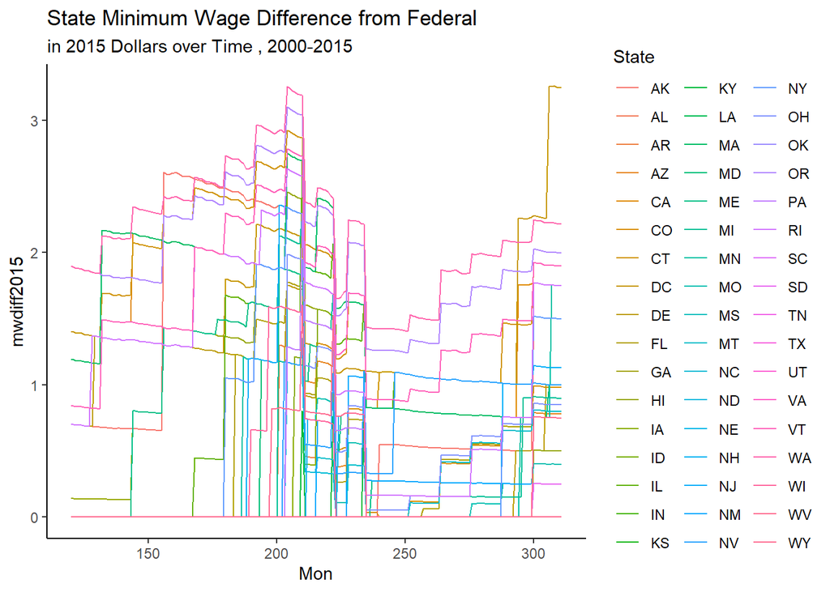

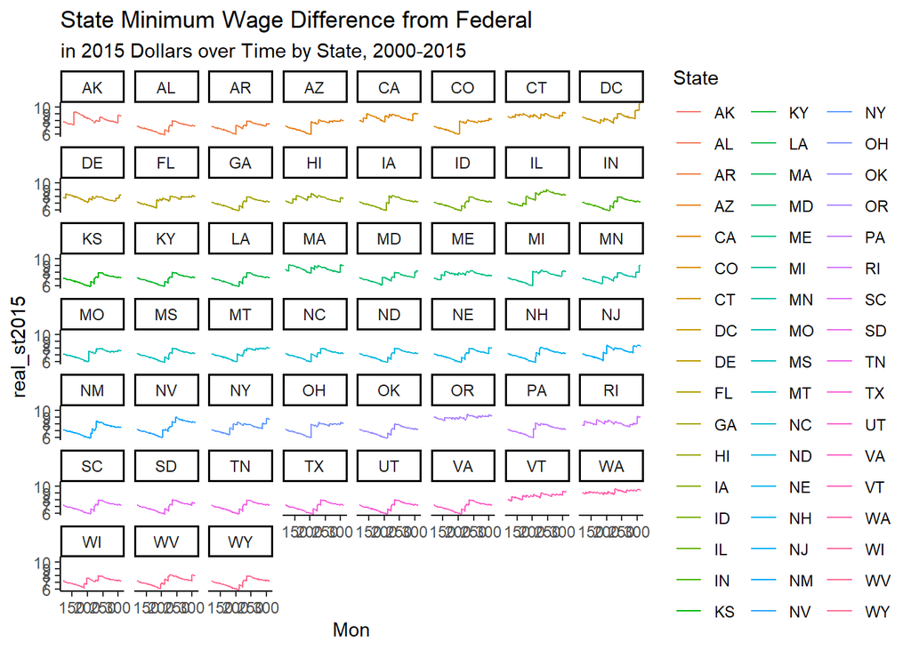

#### Figure 3: Combined plot: Opioid-related deaths over Time by State, 2000-2015

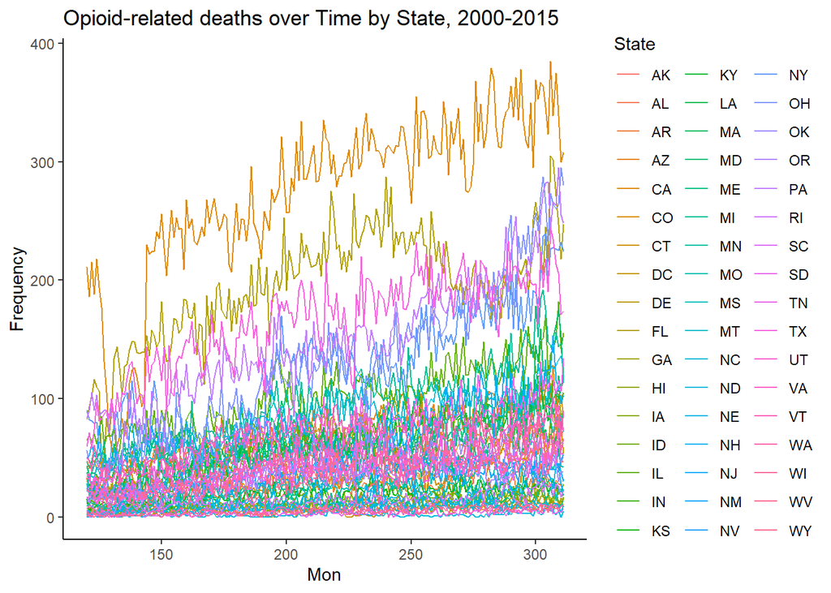

#### Figure 4: Panel plot: Opioid-related deaths over Time by State, 2000-2015

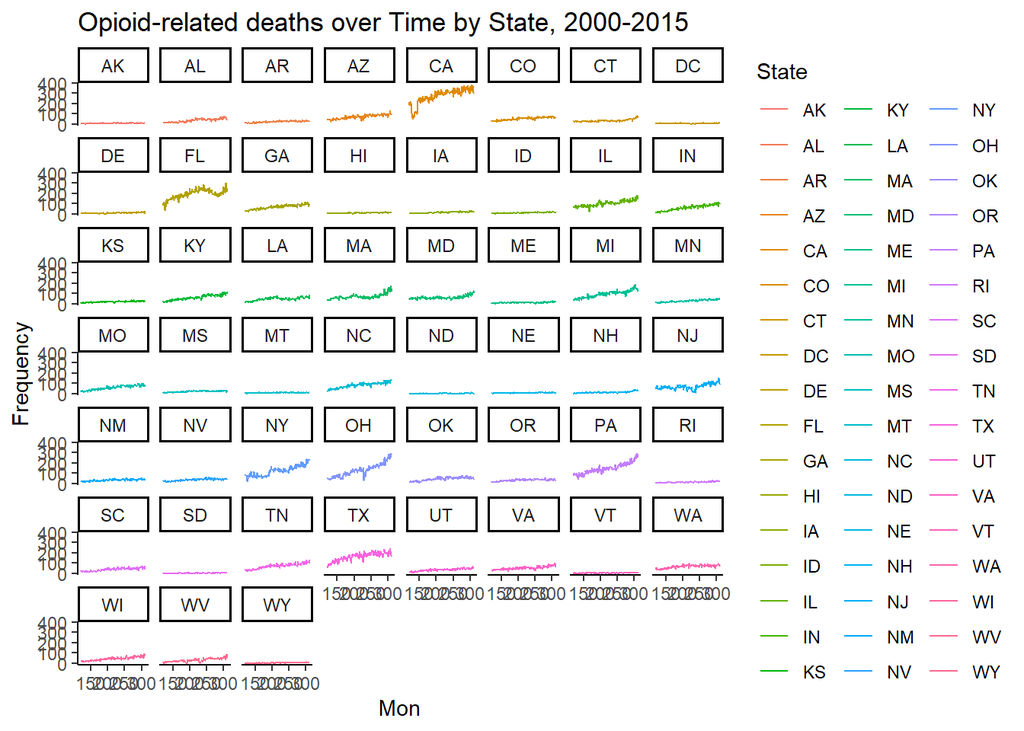

#### Gif 1: Opioid Deaths and Minimum Wage by States from 2000-2015

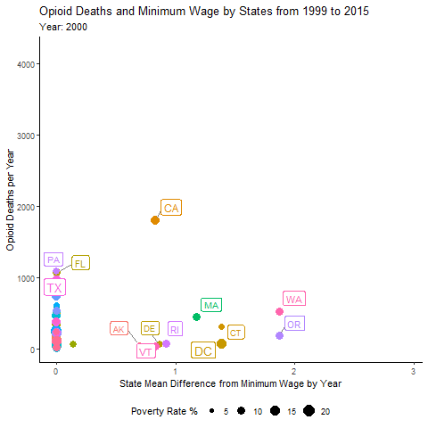

#### Figure 5: Shiny App Screenshot showing ability for users to explore data by select state input, to produce minimum wage difference and opioid deaths plots

[figure not shown]

# Model Summaries

Table 2 includes a summary of models using monthly unlagged state-level minimum wage differences in 2015 dollars as primary predictor in difference-in-difference analyses on outcomes of opioid monthly death counts among the entire US population, high school or less level of education, some college, college graduate, and among males and females.

A 1 US dollar increase in concurrent state-level minimum wage difference from the federal minimum wage for each state month was shown have a significant effect on opioid-related deaths in the overall population, resulting in 3.53 more monthly opioid deaths per state (0.04, 7.01, p = .0475). Additionally, difference-in-difference models indicated that a 1 dollar increase in concurrent state-level minimum wage was shown to result in 1.55 more monthly opioid deaths for women in each state (.19, 2.90, p = .025). Other models using the concurrent state-level minimum wage difference as a predictor were not found to produce results of statistical significance. Overall, confidence intervals for these estimates were wide, with many spanning across 0 and incorporating negative values in parameter estimates.

In the one month lagged models, interestingly, we saw that a 1-month lagged 1 dollar increase in minimum wage no longer had a significant effect on population-level opioid deaths, and also resulted in a wide confidence interval spanning zero (-1.14, 6.82). A similar effect was observed among female opioid deaths, where 1-month lagged 1 dollar increase in minimum wage also no longer had a significant effect in this population (-.07, 3.08). 1 dollar increases in 1-month lagged minimum wage did significantly predict an additional 1.06 deaths (.20, 1.91, p = .015). No other statistically significant results were observed among the primary predictor and outcome variables.

#### Table 2: Unlagged models

**Difference-in-difference models using unlagged minimum wage in 2015 US Dollars as Predictor Variable and Opioid Deaths within each group as outcomes**

|  | *Dependent variable:* |  |  |  |  |  |
| --- | --- | --- | --- | --- | --- | --- |
|  | Population | HS or Less | Some Coll. | Coll. Grad. | Male | Female |
|  | (1) | (2) | (3) | (4) | (5) | (6) |
| mwdiff2015 | 3.53** (0.04, 7.01) | 2.74* (-0.19, 5.67) | 0.79* (-0.06, 1.64) | -0.26 (-1.21, 0.69) | 1.98* (-0.21, 4.16) | 1.55** (0.19, 2.90) |
| Population | -0.0000 (-0.0000, 0.0000) | -0.0000 (-0.0000, 0.0000) | -0.00 (-0.0000, 0.0000) | -0.0000 (-0.0000, 0.0000) | -0.0000** (-0.0000, -0.0000) | -0.0000 (-0.0000, 0.0000) |
| Unemploymentrate | 3.20*** (1.40, 5.01) | 2.15*** (0.78, 3.53) | 0.79*** (0.21, 1.37) | -0.12 (-0.70, 0.46) | 1.92*** (0.83, 3.01) | 1.28*** (0.54, 2.02) |
| PovertyRate | 1.55** (0.30, 2.80) | 1.27** (0.26, 2.27) | 0.30** (0.04, 0.57) | -0.13 (-0.53, 0.27) | 0.99** (0.19, 1.79) | 0.56** (0.10, 1.02) |
| GrossStateProduct | 0.0002*** (0.0002, 0.0003) | 0.0001*** (0.0001, 0.0002) | 0.0001*** (0.0000, 0.0001) | 0.0000** (0.0000, 0.0000) | 0.0002*** (0.0001, 0.0002) | 0.0001*** (0.0000, 0.0001) |
| *Note:* | <sup>⋆</sup>p<0.1;<sup>⋆⋆</sup>p<0.05; <sup>⋆⋆⋆</sup>p<0.01 |  |  |  |  |  |

#### Table 3: 1-month Lagged models

**Difference-in-difference models using 1-month lagged minimum wage in 2015 US Dollars as Predictor Variable**

|  | *Dependent variable:* |  |  |  |  |  |
| --- | --- | --- | --- | --- | --- | --- |
|  | Population | HS or Less | Some Coll. | Coll. Grad. | Male | Female |
|  | (1) | (2) | (3) | (4) | (5) | (6) |
| lag_mwdiff | 2.84 (-1.14, 6.82) | 2.40 (-0.75, 5.54) | 1.06** (0.20, 1.91) | -0.08 (-0.55, 0.40) | 1.33 (-1.14, 3.80) | 1.50* (-0.07, 3.08) |
| Population | -0.0000 (-0.0000, 0.0000) | -0.0000 (-0.0000, 0.0000) | 0.0000 (-0.0000, 0.0000) | -0.0000 (-0.0000, 0.0000) | -0.0000** (-0.0000, -0.0000) | -0.0000 (-0.0000, 0.0000) |
| Unemploymentrate | 3.12*** (1.36, 4.89) | 2.08*** (0.72, 3.45) | 0.76*** (0.19, 1.32) | -0.12 (-0.69, 0.46) | 1.88*** (0.81, 2.96) | 1.24*** (0.52, 1.96) |
| PovertyRate | 1.58** (0.30, 2.85) | 1.29** (0.26, 2.32) | 0.31** (0.04, 0.58) | -0.13 (-0.53, 0.27) | 1.00** (0.19, 1.82) | 0.57** (0.10, 1.05) |
| GrossStateProduct | 0.0002*** (0.0002, 0.0003) | 0.0001*** (0.0001, 0.0002) | 0.0001*** (0.0000, 0.0001) | 0.0000** (0.0000, 0.0000) | 0.0002*** (0.0001, 0.0002) | 0.0001*** (0.0000, 0.0001) |
| *Note:* | <sup>⋆</sup>p<0.1;<sup>⋆⋆</sup>p<0.05; <sup>⋆⋆⋆</sup>p<0.01 |  |  |  |  |  |

## Discussion

This study adds to the body of research assessing the complex relationships between potential economic policy interventions and outcomes of opioid mortality. The null or significant findings from the majority of difference-in-difference analyses could suggest that minimum wage may at least not have a protective effect as theorized by research surrounding economic impacts on drug overdoses as a “disease of despair.”

The differences in unlagged effects versus lagged effects of 1 dollar minimum wage increases are interesting to note, and may point to a more immediate effect of minimum wage increases on opioid overdoses. Further research may be needed to delve into the time period between when minimum wage is increased at the state level to when wage increases are experienced by minimum-wage level employees.

Significant effects between minimum wage increases and female opioid deaths are interesting to note, as women are estimated to comprise ~60% of the minimum wage workforce, indicating that women may be more sensitive to experiencing the effects of minimum wage increases as a public health intervention than men are (Bradley 2021).

While many models resulted in null estimates, with confidence intervals spanning 0, the positive direction of the relationship between state-level minimum wage increases and opioid deaths poses several questions that should be considered as public health policy researchers consider utilizing this policy as a public health intervention. One area worth exploring is a deeper understanding of the true economic impact of minimum wage increases to their overall disposable income, and how this increase may be related to health. Existing research in this area has continued to produce mixed effects, particularly in the context of mental health and drug and alcohol abuse outcomes (Horn, Maclean, and Strain 2017)(Sabia, Pitts, and Argys 2019). Exploring how this increase relates to access and demand for opioids and other drugs remains an area of importance for future research. Expanding this analyses to longer time periods may also improve the ability to determine trends in these relationships. A limitation into determining the continuum of intervention effect of minimum wage in this study is present due to the limited range of minimum wage increases found in our sample (range: 0, 3.26 dollars). Stronger intervention effects may be identified as future wage increases surpass the amounts reported in our data. Another potential limitation of this study is that it has been shown that for data reported that 1 in 5 death records lacked any information on drugs, which may mean that our data may underestimate actual opioid counts (Rudd et al. 2016).

While the benefits and risks associated with increasing state-level minimum wage continue to be debated, it is important to consider its efficacy as a public health instrument, as one that may produce blunt and unintended effects on populations needing more targeted public health infrastructure and assistance to avoid succumbing to the “diseases of despair.”

### References

Bradley, David H. 2021. “The Federal Minimum Wage: In Brief,” February, 12.

Horn, Brady P., Johanna Catherine Maclean, and Michael R. Strain. 2017. “Do Minimum Wage Increases Influence Worker Health?” *Economic Inquiry* 55 (4): 1986–2007. https://doi.org/https://doi.org/10.1111/ecin.12453.

Kaufman, John A., Leslie K. Salas-Hernández, Kelli A. Komro, and Melvin D. Livingston. 2020. “Effects of Increased Minimum Wages by Unemployment Rate on Suicide in the USA.” *J Epidemiol Community Health* 74 (3): 219–24. https://doi.org/10.1136/jech-2019-212981.

Knapp, Emily A., Usama Bilal, Lorraine T. Dean, Mariana Lazo, and David D. Celentano. 2019. “Economic Insecurity and Deaths of Despair in US Counties.” *American Journal of Epidemiology* 188 (12): 2131–39. https://doi.org/10.1093/aje/kwz103.

Lechner, Michael. 2011. “The Estimation of Causal Effects by Difference-in-Difference Methods.” *Foundations and Trends® in Econometrics* 4 (3): 165–224. https://doi.org/10.1561/0800000014.

Mulligan, Casey B. 2021. “Deaths of Despair and the Incidence of Excess Mortality in 2020.” https://doi.org/10.3386/w28303.

National Institute on Drug Abuse. 2021. “Overdose Death Rates.” https://www.drugabuse.gov/drug-topics/trends-statistics/overdose-death-rates.

Rudd, Rose A., Puja Seth, Felicita David, and Lawrence Scholl. 2016. “Increases in Drug and Opioid-Involved Overdose Deaths United States, 20102015.” *MMWR. Morbidity and Mortality Weekly Report* 65 (5051): 1445–52. https://doi.org/10.15585/mmwr.mm655051e1.

Ruhm, Christopher J. 2018. “Deaths of Despair or Drug Problems?” https://doi.org/10.3386/w24188.

Sabia, Joseph J., M. Melinda Pitts, and Laura M. Argys. 2019. “Are Minimum Wages a Silent Killer? New Evidence on Drunk Driving Fatalities.” *The Review of Economics and Statistics* 101 (1): 192–99. https://doi.org/10.1162/rest_a_00761.